# EDA inicial

David Eduardo, José Renan, Juan Victor, Lívia Cavalcanti

19 de maio de 2019

```r
reclamacoes <- read_csv("../data/3-avaliacao-humana/reclamacoes-avaliadas-20190515.csv")
```

## Quais os pontos mais frequentes nas reclamações dos usuários?

Uma forma de obter o resumo das reclamações é analisar quais as palavras mais citadas nas reclamações. Com isso, é possível ter uma ideia do que mais gera insatisfação entre os consumidores.

Como primeira análise, verificamos quais as palavras mais frequentes no texto, eliminando, para isso, expressões muito frequentes da Língua Portuguesa, como verbos de ligação, pronomes e conjunções, conhecidas como *stopwords*. É preciso filtrar essas classes de palavras, porque são as que possuem maior frequência na maioria dos textos, ao mesmo tempo que menos transmitem o assunto sendo tratados neles.

```r
stopwords_br = c(stopwords(kind="pt"), c("é", "r", "sendo", "pois", "ser", "desde", "pode", "ainda"))

reclamacoes_palavras <- reclamacoes %>%
  select(texto, orgao) %>%
  unnest_tokens(palavra, texto) %>%
  filter(!palavra %in% stopwords_br) %>%
  count(orgao, palavra, sort = TRUE) %>%
  filter(is.na(as.numeric(palavra)))

total_palavras <- reclamacoes_palavras %>%
  group_by(orgao) %>%
  summarize(total = sum(n))

reclamacoes_palavras <- left_join(reclamacoes_palavras, total_palavras)

head(reclamacoes_palavras)
```

```
## # A tibble: 6 x 4
##   orgao  palavra     n total
##   <chr>  <chr>   <int> <int>
## 1 ANS    saúde      45  2119
## 2 ANATEL dia        44  2683
## 3 ANATEL empresa    35  2683
## 4 ANATEL vivo       35  2683
## 5 ANS    ans        34  2119
## 6 ANATEL tim        32  2683
```

Pelos gráficos abaixo, podemos ver que para ambas as agências são recorrentes as citações de empresas prestadoras, além de problemas com plano e serviço, conta e reembolso, protocolos e ligações. Ou seja, mesmo em áreas diferentes, as reclamações recaem nos mesmos problemas.

É importante notar que a análise está sendo feita sob o ponto de vista de proporção entre a frequência da palavra pelo total de palavras que não são *stopwords*.

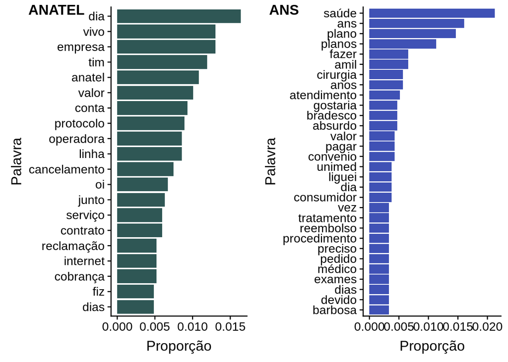

```r
top_20 <- reclamacoes_palavras %>% filter(is.na(as.numeric(palavra))) %>% group_by(orgao) %>% top_n(n=20, wt=n) %>% mutate(prop= n/total)
ans_grafico <- top_20 %>%
                ggplot(aes(x=reorder(palavra, prop), y=prop, fill = orgao)) +
                  geom_histogram(data = subset(top_20, orgao=="ANS"),show.legend = FALSE, stat = "identity", fill="#3f51b5")+
                    labs(x="Palavra", y="Proporção") +
                      coord_flip()

anatel_grafico <- top_20 %>%
                    ggplot(aes(x=reorder(palavra, prop), y=prop, fill = orgao)) +
                      geom_histogram(data = subset(top_20, orgao=="ANATEL"),show.legend = FALSE, stat = "identity", fill="#2f5755")+
                          labs(x="Palavra", y="Proporção") +
                            coord_flip()

plot_grid(anatel_grafico, ans_grafico, labels = c('ANATEL', 'ANS'))
```

## Análise de texto

Agora analisaremos métricas sobre os dados da coluna que indica as reclamações. Inicialmente, verificaremos as principais métricas sobre a quantidade de caracteres em cada reclamação:

```r
summary(nchar(reclamacoes$texto))
```

```
##    Min. 1st Qu.  Median    Mean 3rd Qu.    Max.
##    45.0   427.8   670.5   906.3  1158.2  3522.0
```

É possível verificar que há uma variação muito grande na quantidade de caracteres usados no caso mínimo(45 caracteres) e no caso máximo(3522 caracteres). É possível notar também que a média e a mediana estão ligeiramente distantes, levando a conclusão que os valores do último quartil estão influenciando na média.

Para verificar melhor essas condições, segue o histograma da quantidade de caracteres em cada reclamação:

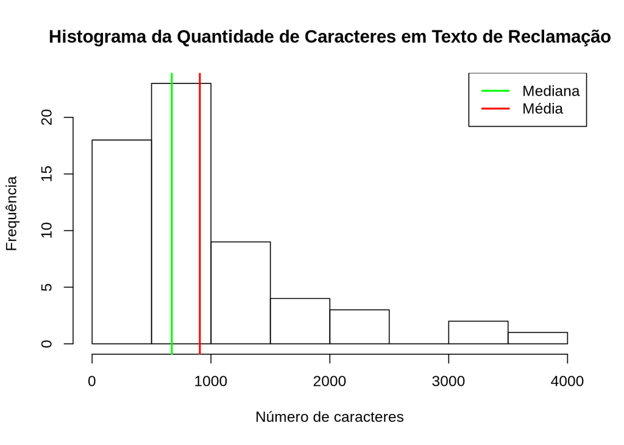

```r
hist(nchar(reclamacoes$texto), main = "Histograma da Quantidade de Caracteres em Texto de Reclamação",
     xlab="Número de caracteres", ylab="Frequência")
abline(v = mean(nchar(reclamacoes$texto)), col = "red", lwd = 2)
abline(v=median(nchar(reclamacoes$texto)), col="green",lwd=2)
legend(x="topright", #posicao da legenda
c("Mediana","Média"), #nomes da legenda
col=c("green","red"),
lty=c(1,1), #estilo da linha
lwd=c(2,2))
```

Outra forma de avaliar esses valores é através do boxplot:

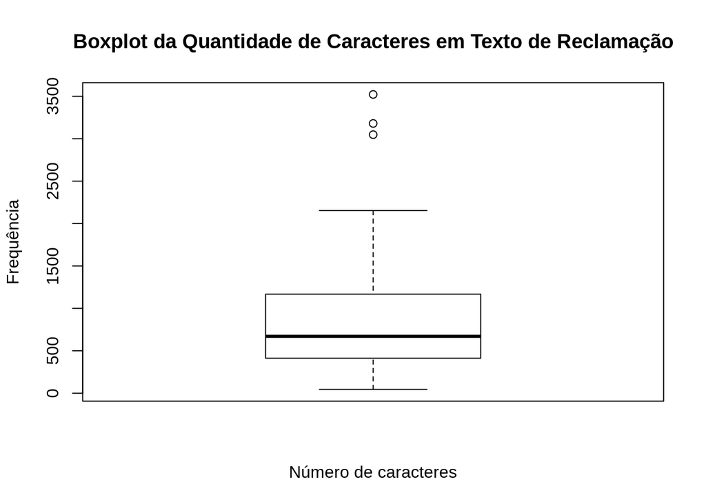

```r
boxplot(nchar(reclamacoes$texto), main = "Boxplot da Quantidade de Caracteres em Texto de Reclamação",
     xlab="Número de caracteres", ylab="Frequência")
```

É possível verificar que existem 3 outliers na parte superior, confirmando a hipótese de que a média está sofrendo influência desses valores.

Existe correlação entre o grau de insatisfação e os orgãos ? Algum orgão apresenta um nível de insatisfação maior ?

```r
reclamacoes <- read_csv("../data/3-avaliacao-humana/reclamacoes-avaliadas-20190515.csv")
reclamacoes %>%
    group_by(orgao) %>%
    summarise(media = mean(insatisfacao))
```

```
## # A tibble: 2 x 2
##   orgao  media
##   <chr>  <dbl>
## 1 ANATEL  2.42
## 2 ANS     2.85
```

Analisando as médias calculadas acima a ANS parece ter um nível maior de insatisfação.

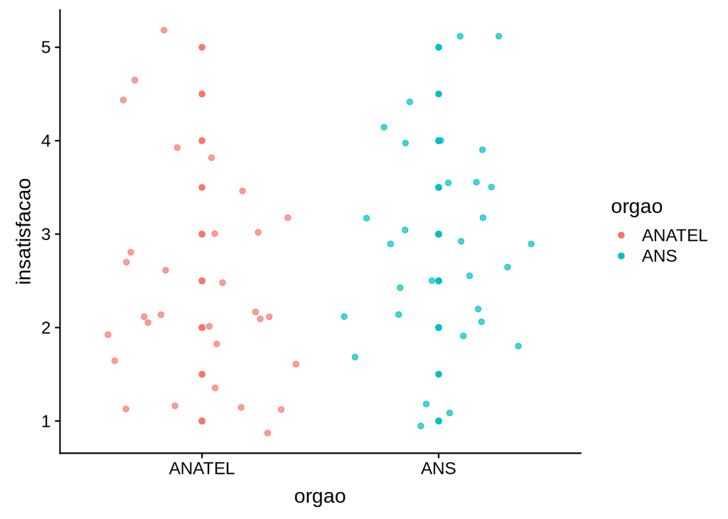

```r
reclamacoes %>%
    ggplot(aes(y = insatisfacao, x = orgao,  color = orgao)) +
    geom_jitter(alpha = .7) +
    geom_point()
```

As médias de insatisfação entre os dois orgãos apresentam uma diferença pequena e quase insignificate de 0.43. O gráfico acima mostra que não parece existir uma contração de valores para um determinado orgão. O que nos leva a concluir que não existe uma relação entre orgão e nível de insatisfação.

Existe correlação entre o grau de insatisfação e o horário que foi feita a reclamação ?

Foi realizado uma classificação para os horarios: 1 - Madrugada * 2 - Almoço * 3 - Outra

```r
reclamacoes <- read_csv("../data/3-avaliacao-humana/reclamacoes-avaliadas-20190515.csv")
reclamacoes <- reclamacoes %>%
      mutate(a = lubridate::dmy_hm(data),
             b = lubridate::hour(a),
             horario = ifelse(( b >= 0 & b <= 6), 1,
                          ifelse(( b >= 11 & b <= 13), 2, 3 )))
```

```r
reclamacoes %>%
    group_by(horario) %>%
    summarise( media =  mean(insatisfacao))
```

```
## # A tibble: 3 x 2
##   horario media
##     <dbl> <dbl>
## 1       1  4
## 2       2  2.96
## 3       3  2.51
```

Como só tivemos uma única reclamação que foi feita durante a madrugada não podemos utilizar essa informação. Porém o que as médias mostram é que as pessoas parecem fazer reclamações com maior nível de insatisfação durante o horário do almoço, com uma média de 2.96. Enquanto em outros horarios temos uma média de 2.51.